# **HEART DISEASE PREDICTION**

# 1.EDA

```python
import pandas as pd
r=pd.read_csv('C:\\Users\\YAKSHITHA DONTHI\\Downloads\\Heart_Disease_Data.txt')
r.to_csv('C:\\Users\\YAKSHITHA DONTHI\\Downloads\\finalcleve.csv',index=None)
```

```python
%matplotlib inline
```

```python
df = pd.read_csv('C:\\Users\\YAKSHITHA DONTHI\\Downloads\\finalcleve.csv', na_values='?')
df.head()
```

|  | age | sex | cp | trestbps | chol | fbs | restecg | thalach | exang | oldpeak | slop | ca | thal | pred_attribute |
| --- | --- | --- | --- | --- | --- | --- | --- | --- | --- | --- | --- | --- | --- | --- |
| 0 | 63 | 1 | 1 | 145 | 233 | 1 | 2 | 150 | 0 | 2.3 | 3 | 0.0 | 6.0 | 0 |
| 1 | 67 | 1 | 4 | 160 | 286 | 0 | 2 | 108 | 1 | 1.5 | 2 | 3.0 | 3.0 | 2 |
| 2 | 67 | 1 | 4 | 120 | 229 | 0 | 2 | 129 | 1 | 2.6 | 2 | 2.0 | 7.0 | 1 |
| 3 | 37 | 1 | 3 | 130 | 250 | 0 | 0 | 187 | 0 | 3.5 | 3 | 0.0 | 3.0 | 0 |
| 4 | 41 | 0 | 2 | 130 | 204 | 0 | 2 | 172 | 0 | 1.4 | 1 | 0.0 | 3.0 | 0 |

```python
df.shape
```

```
(303, 14)
```

```python
df.info()
```

[output not shown]

```python
df.describe()
```

|  | age | sex | cp | trestbps | chol | fbs | restecg | thalach | exang | oldpeak | slop | ca | thal | pred_attribute |
| --- | --- | --- | --- | --- | --- | --- | --- | --- | --- | --- | --- | --- | --- | --- |
| count | 303.000000 | 303.000000 | 303.000000 | 303.000000 | 303.000000 | 303.000000 | 303.000000 | 303.000000 | 303.000000 | 303.000000 | 303.000000 | 299.000000 | 301.000000 | 303.000000 |
| mean | 54.438944 | 0.679868 | 3.158416 | 131.689769 | 246.693069 | 0.148515 | 0.990099 | 149.607261 | 0.326733 | 1.039604 | 1.600660 | 0.672241 | 4.734219 | 0.937294 |
| std | 9.038662 | 0.467299 | 0.960126 | 17.599748 | 51.776918 | 0.356198 | 0.994971 | 22.875003 | 0.469794 | 1.161075 | 0.616226 | 0.937438 | 1.939706 | 1.228536 |
| min | 29.000000 | 0.000000 | 1.000000 | 94.000000 | 126.000000 | 0.000000 | 0.000000 | 71.000000 | 0.000000 | 0.000000 | 1.000000 | 0.000000 | 3.000000 | 0.000000 |
| 25% | 48.000000 | 0.000000 | 3.000000 | 120.000000 | 211.000000 | 0.000000 | 0.000000 | 133.500000 | 0.000000 | 0.000000 | 1.000000 | 0.000000 | 3.000000 | 0.000000 |
| 50% | 56.000000 | 1.000000 | 3.000000 | 130.000000 | 241.000000 | 0.000000 | 1.000000 | 153.000000 | 0.000000 | 0.800000 | 2.000000 | 0.000000 | 3.000000 | 0.000000 |
| 75% | 61.000000 | 1.000000 | 4.000000 | 140.000000 | 275.000000 | 0.000000 | 2.000000 | 166.000000 | 1.000000 | 1.600000 | 2.000000 | 1.000000 | 7.000000 | 2.000000 |
| max | 77.000000 | 1.000000 | 4.000000 | 200.000000 | 564.000000 | 1.000000 | 2.000000 | 202.000000 | 1.000000 | 6.200000 | 3.000000 | 3.000000 | 7.000000 | 4.000000 |

```python
print("No of Nan values in our dataframe : ", sum(df.isnull().any()))
```

[output not shown]

```python
df.isnull().sum()
```

```
age               0
sex               0
cp                0
trestbps          0
chol              0
fbs               0
restecg           0
thalach           0
exang             0
oldpeak           0
slop              0
ca                4
thal              2
pred_attribute    0
dtype: int64
```

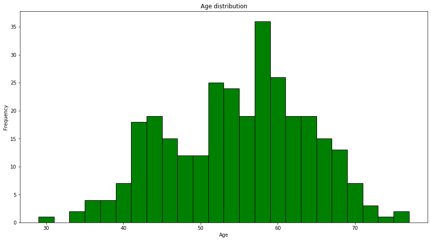

```python
import matplotlib.pyplot as plt
plt.figure(figsize=(15,8))
plt.hist(df['age'], color='green', edgecolor='black', bins=24)
plt.xlabel('Age')
plt.ylabel('Frequency')
plt.title('Age distribution')
plt.show()
```

```python
male = df['sex'].sum() # '1' indicates male and '0' indicates female
print('There are '+ str(male) + ' males and '+ str(df.shape[0] - male) + ' females in the dataset')
```

```
There are 206 males and 97 females in the dataset
```

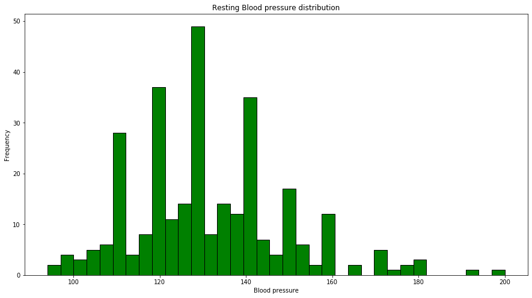

```python
plt.figure(figsize=(15,8))
plt.hist(df['trestbps'], color='green', edgecolor='black', bins=int(106/3))
plt.xlabel('Blood pressure')
plt.ylabel('Frequency')
plt.title('Resting Blood pressure distribution')
plt.show()
```

Blood pressure of 130 value is more in the dataset, next is 120 and so on

```python
df.groupby('cp')['cp'].count()
```

```
cp
1     23
2     50
3     86
4    144
Name: cp, dtype: int64
```

It says chest pain of type angina, abnang, notang, asympt are 23,50,86,144 rows respectively.

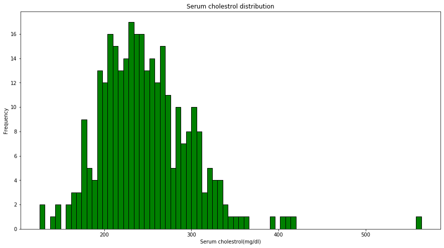

```python
plt.figure(figsize=(15,8))
plt.hist(df['chol'], color='green', edgecolor='black', bins=73)
plt.xlabel('Serum cholestrol(mg/dl)')
plt.ylabel('Frequency')
plt.title('Serum cholestrol distribution')
plt.show()
```

Most of the cholestrol rates are between 200 and 300

```python
df.groupby('restecg')['restecg'].count()
```

```
restecg
0    151
1      4
2    148
Name: restecg, dtype: int64
```

It says most of rows resting ecg is either normal or hyper

```python
diabetic = df['fbs'].sum() # '1' indicates yes and '0' indicates no about resting blood sugar
print('There are '+ str(diabetic) + ' patients who had resting blood sugar > 120 mg/dl(diabetic) out of the '+ str(df.shape[0]) + ' patients')
```

```
There are 45 patients who had resting blood sugar > 120 mg/dl(diabetic) out of the 303 patients
```

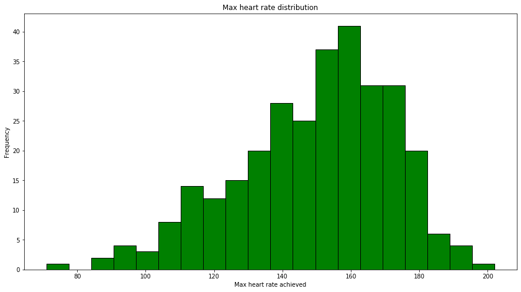

```python
plt.figure(figsize=(15,8))
plt.hist(df['thalach'], color='green', edgecolor='black', bins=20)
plt.xlabel('Max heart rate achieved')
plt.ylabel('Frequency')
plt.title('Max heart rate distribution')
plt.show()
```

Max heart rate is between 140 to 180 which is permissible level

```python
eig = df['exang'].sum() # '1' indicates yes and '0' indicates no about exercise induced angina
print('There are '+ str(eig) + ' patients who had exercise induced angina out of the '+ str(df.shape[0]) + ' patients')
```

```
There are 99 patients who had exercise induced angina out of the 303 patients
```

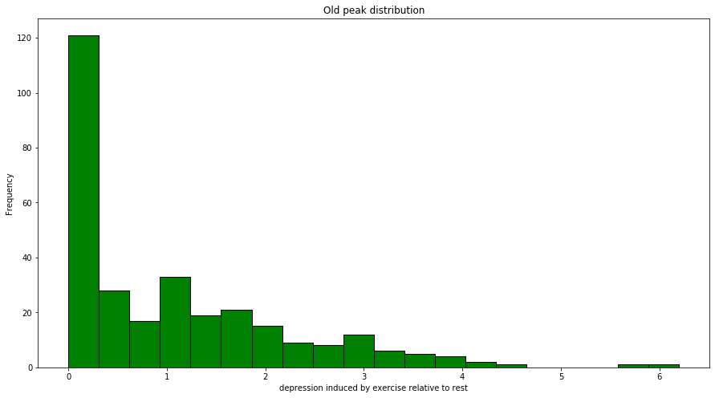

```python
plt.figure(figsize=(15,8))
plt.hist(df['oldpeak'], color='green', edgecolor='black', bins=20)
plt.xlabel('depression induced by exercise relative to rest')
plt.ylabel('Frequency')
plt.title('Old peak distribution')
plt.show()
```

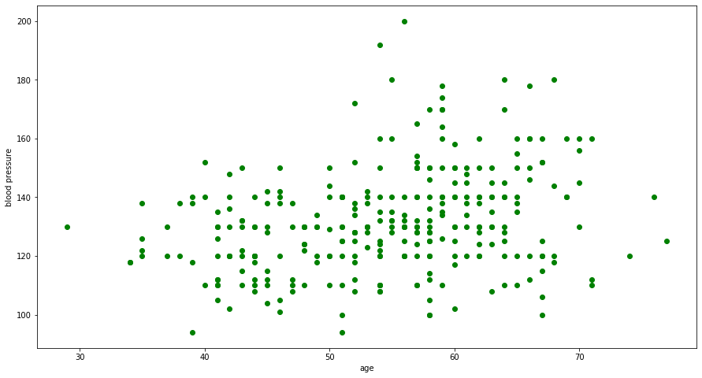

```python
plt.figure(figsize=(15,8))
plt.scatter(df['age'],df['trestbps'],c='green')
plt.xlabel('age')
plt.ylabel('blood pressure')
```

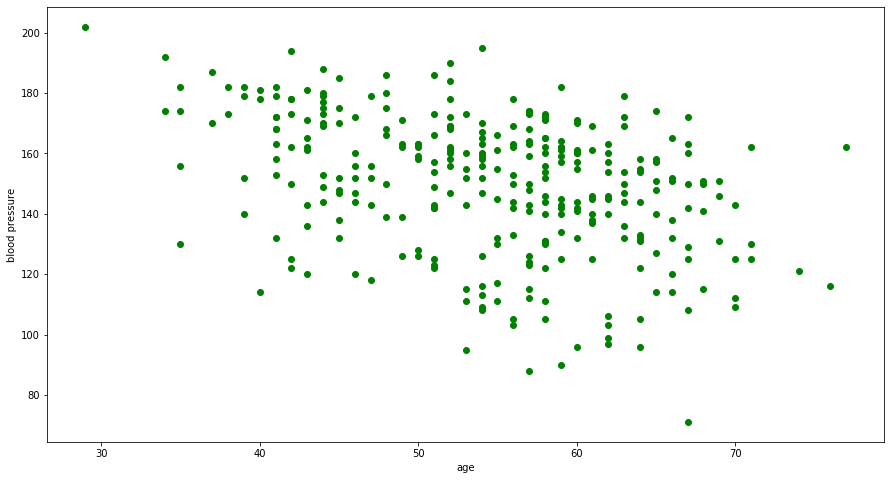

```python
plt.figure(figsize=(15,8))
plt.scatter(df['age'],df['thalach'],c='green')
plt.xlabel('age')
plt.ylabel('blood pressure')
```

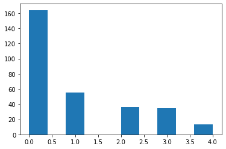

```python
plt.hist(df['pred_attribute'])
```

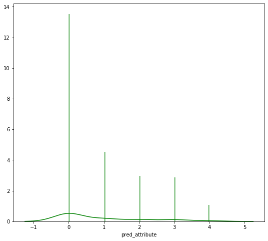

```python
plt.figure(figsize=(9, 8))
sns.distplot(df['pred_attribute'], color='g', bins=100, hist_kws={'alpha': 0.4});
```

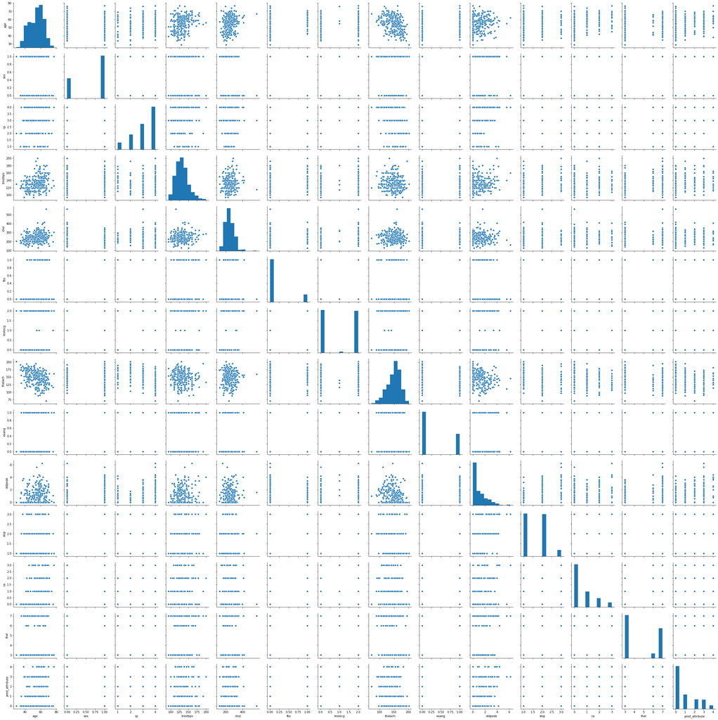

```python
import seaborn as sns
sns.pairplot(df)
```

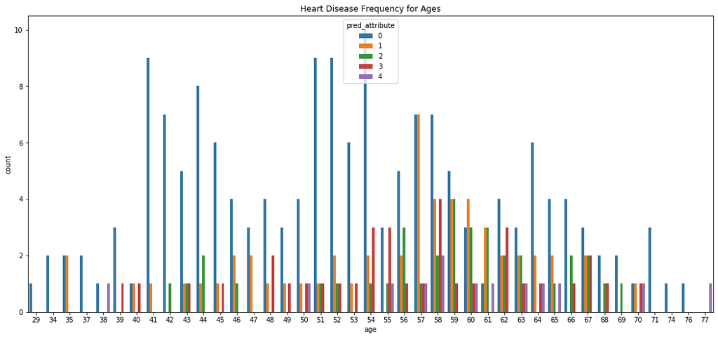

```python
import seaborn as sns
plt.figure(figsize=(18,8))
sns.countplot(x='age', data = df, hue="pred_attribute")
plt.title('Heart Disease Frequency for Ages')
```